#### ▶ 정당지지도

더불어민주당 38.8%, 국민의힘 32.4%, 조국혁신당 10.7%, 개혁신당 6.5%, 기타 정당 3.7%, 지지하는 정당 없다 7.1%, 잘 모르겠다 0.8%

#### ▶ 국정평가

잘하고 있다 30.3%, 잘못하고 있다 67.0%, 잘 모르겠다 2.7%

#### ☑ 차기 대권 주자 적합도

김동연 2.5%, 안철수 1.8%, 오세훈 3.9%, 원희룡 4.6%, 이재명 39.6%, 이준석 6.3%, 조국 7.5%, 한동훈 22.8%, 홍준표 4.4%, 그 외 다른 인물 1.5%, 없다 3.9%, 잘 모르겠다 1.2%

#### ☑ 해병대원 특검법 찬반

매우 찬성한다 56.3%, 대체로 찬성한다 10.0%, 대체로 반대한다 11.3%, 매우 반대한다 15.6%, 잘 모르겠다 6.8%

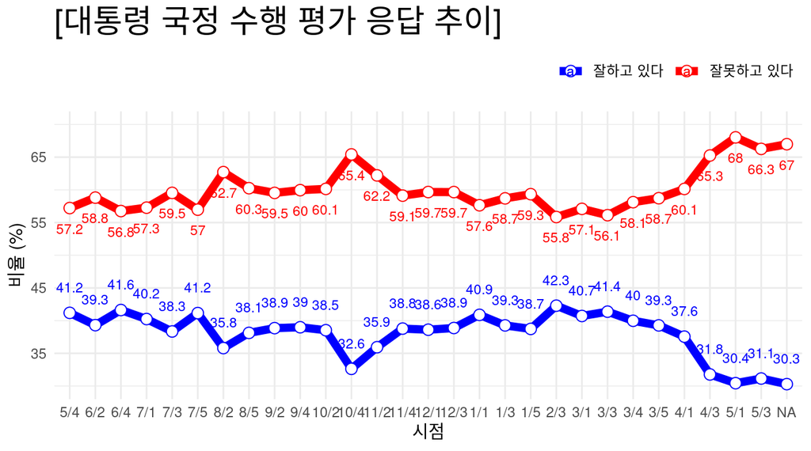

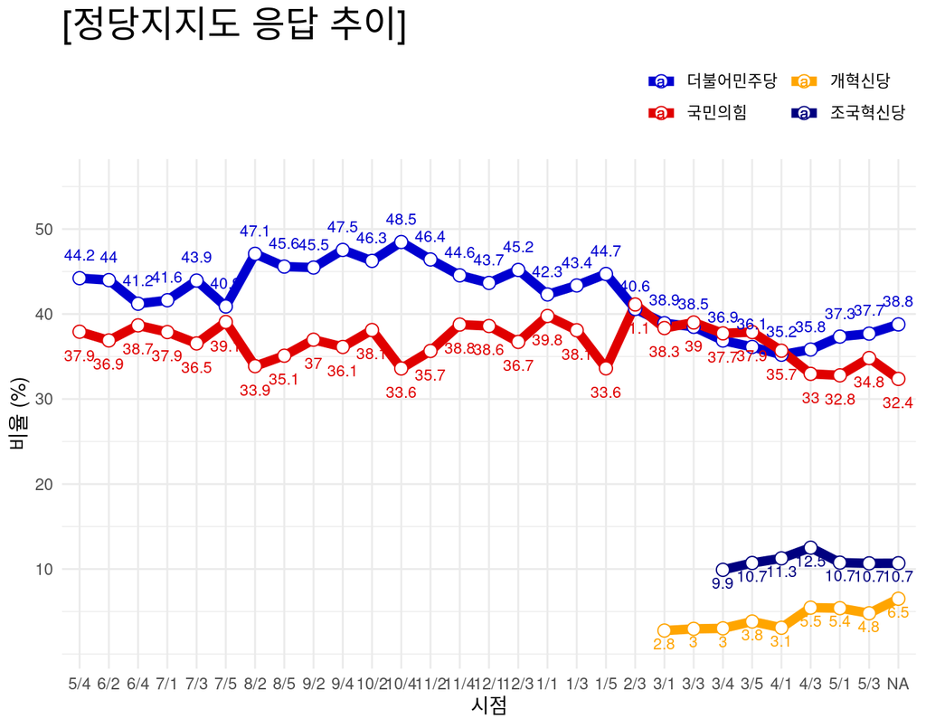

### 추가사항

- [주요질문 / 집단별 세부통계 보기](https://modernity.shinyapps.io/survey_str/) (링크누르시오)

### 참고사항

- 표본수: 2,004명,표본오차는 95% ±2.2%p
- 조사정보: 스트레이트뉴스의 의뢰로 조원씨앤아이가 2024년 5월 11일~13일 3일간

  전국 만 18세 이상 남녀를 대상으로 ARS 여론조사

  (휴대전화 100% RDD 방식, 성,연령대,지역별 비례할당 후 무작위 추출)를 실시한 결과이며,

  표본수는 2,004(총 통화시도 83,240명, 응답률 2.4%)

  ※ 가중치 부여 방식: [림가중] 성별, 연령별, 지역별 가중값 부여(2024년 4월말 행정안전부 발표 주민등록인구기준)
- [중앙선거여론조사심의위원회](https://nesdc.go.kr/portal/bbs/B0000005/list.do?menuNo=200467)에서 관련사항 확인가능

[figure not shown]

2024.05.28 (Tue) 17:25 제작

- 연구개발 단계입니다.
- 제공: 감동과 마음의 [조원씨앤아이](http://jowoncni.com/html/index.html)